# 5.Closest genes to random positions

TODO: see whether any genes in particular come up in the lists. https://www.datacamp.com/community/tutorials/tidyverse-exploratory-analysis

# Closest gene

Some analyses performed on sequencing data use genes as the basis for analysis. In RNA-seq for example, a table of count data is often produced where a value for a gene is calculated by counting reads that fall within or overlap the gene. Some analyses are not directly based around genes. A common method used in ChIP-seq analysis is peak calling, where a test sample is generally compared to a background sample to identify regions that have a high read count in the test sample. These peaks may be exonic or intronic and can simply be annotated with the overlapping gene. The peaks may also be intergenic in which case they are often annotated with the closest gene.

Genes vary greatly in size and the spread of genes is not uniform across chromosomes. It may be expected that longer genes, genes in the middle of gene deserts and those at the ends of clusters of genes are identified more frequently when annotating data with the closest gene to a region of interest.

The aim of this study was to see whether any biases were found when annotating random positions within the genome with the closest gene. This was carried out using the following steps:

- generating random locations within the mouse genome and annotating these with the closest gene
- seeing whether any particular genes were overrepresented
- performing GO analyses on the lists of closest genes

## Generating genes by random position

The python script `generate_genelist_from_random_positions.py` produces a list of 200 genes. It generates a number of random positions along each chromosome. The number of positions generated is proportional to the length of the chromosome. The chromosome lengths are taken from a separate file (`chr_list.txt`) A gtf file containing all the genes in the genome is required. Each line from the gtf file is parsed and all the genes are stored by chromosome. Each random position is looped through to find the closest (or overlapping) gene and the output is written to a new file. This script has been run to create lists of genes for the mouse genome using the gtf file for genome version GRCm38.95

`for i in {1..200}; do qsub -cwd -V -l h_vmem=10G python ./generate_genelist_from_random_positions.py` `--output gene_lists_GRCm38.95/closest_genes_${i}.txt; done`

Extract the gene names and remove header `for i in closest*; do cut -f2 $i | tail -n 200 > ${i%".txt"}_just_genes.txt; done`

### Checking for overrepresentation at the gene level

There are 200 sets of 200 genes. We can plot out which genes appear the most often in the 200 sets. The top hit, Gm20388, appears 69 times. (Does each gene only appear once per list? I don’t think I filter on that.)

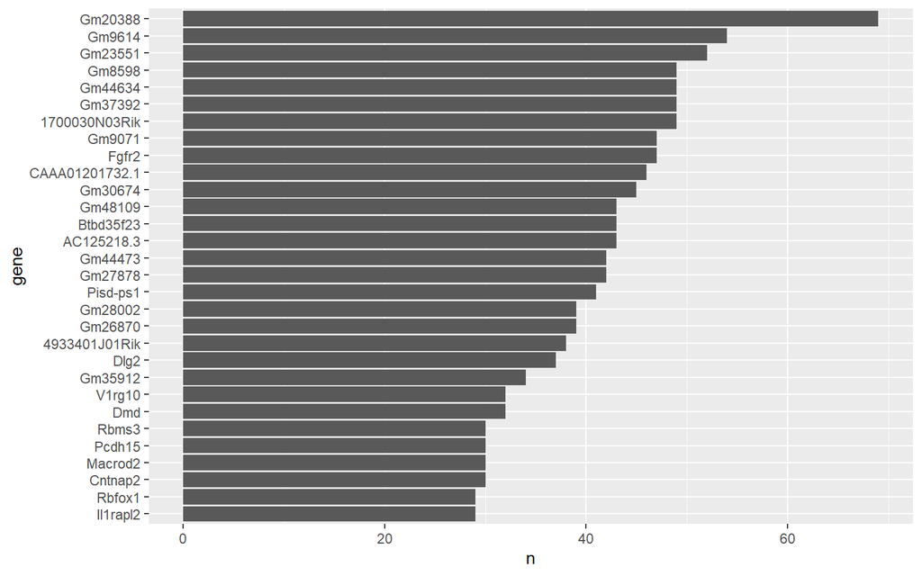

### Evaluating locations in SeqMonk

The output of the `generate_genelist_from_random_positions.py` script contains the locations of the genes in the genome, along with the distance from the randomly generated position. 200 of these files were generated. The files can be concatenated and loaded into SeqMonk to explore the data. Concatenate the files: `info_files=$(ls closest_genes* | ls !(*just_genes*))` `head closest_genes_1.txt -n 1 > all_closest_gene_info.txt` `for i in $info_files; do tail -n 200 $i >> all_closest_gene_info.txt; done`

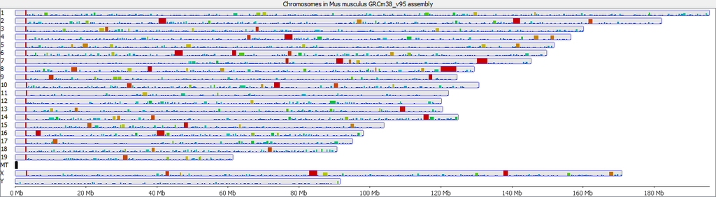

closest genes image

The first gene on the chromosome is highlighted on the SeqMonk plot.

|  | gene_name | length | n | first_genes | longer_than_1mb | gene_characteristics |
| --- | --- | --- | --- | --- | --- | --- |
| 1 | Gm20388 | 4434881 | 69 | no | True | long_gene |
| 2 | Gm9614 | 881 | 54 | yes | False | first_gene |
| 3 | Gm23551 | 120 | 52 | yes | False | first_gene |
| 4 | 1700030N03Rik | 132003 | 49 | yes | False | first_gene |
| 5 | Gm37392 | 515 | 49 | yes | False | first_gene |
| 6 | Gm44634 | 151 | 49 | yes | False | first_gene |
| 7 | Gm8598 | 835 | 49 | yes | False | first_gene |
| 8 | Fgfr2 | 2960899 | 47 | no | True | long_gene |
| 9 | Gm9071 | 1870 | 47 | yes | False | first_gene |
| 10 | CAAA01201732.1 | 279 | 46 | yes | False | first_gene |

[output cut: 18098 more lines]

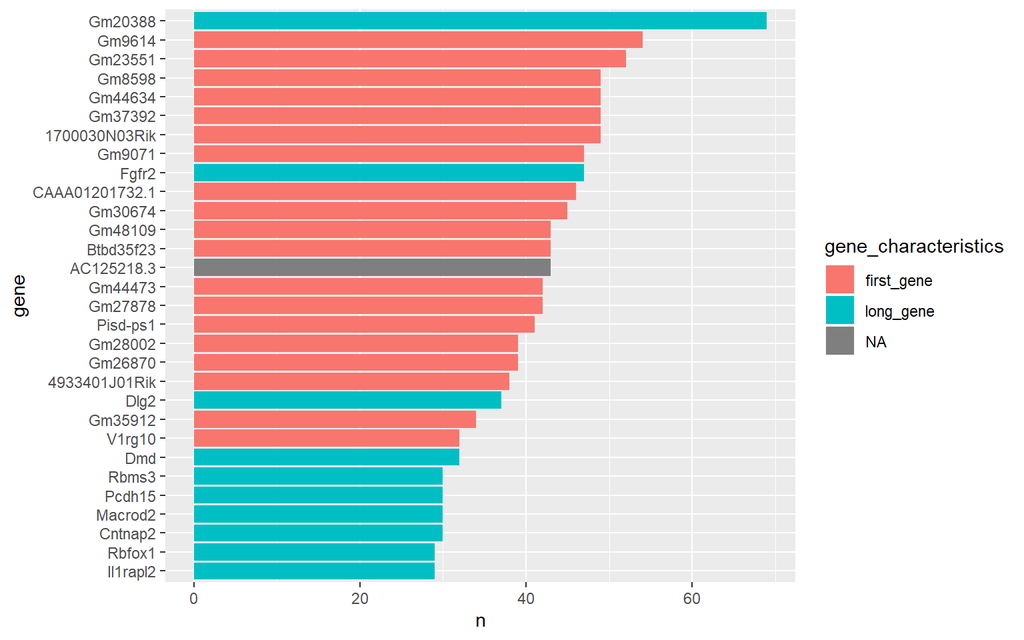

### Plot number of times a gene appeared vs its length

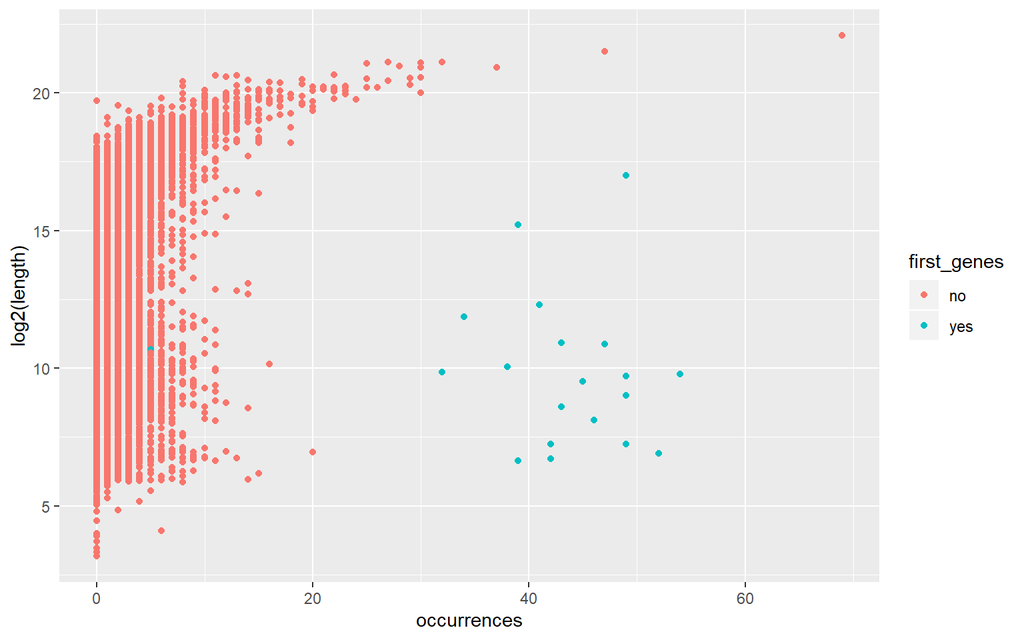

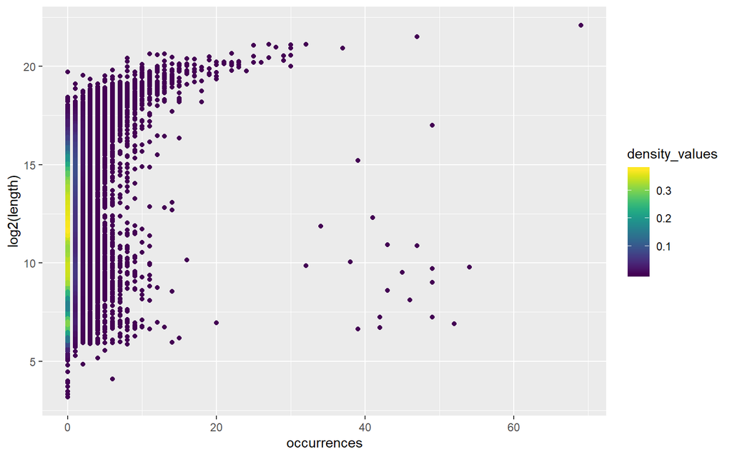

## Gene ontology analysis

Each of the 200 sets of genes was run through a gene ontology analysis

The number of gene sets that returned significant results from the GO overrepresentation analysis

In this set, we had 200 sets of gene lists, while in the others we had 100 per category. We’ll therefore double the cut-off value.

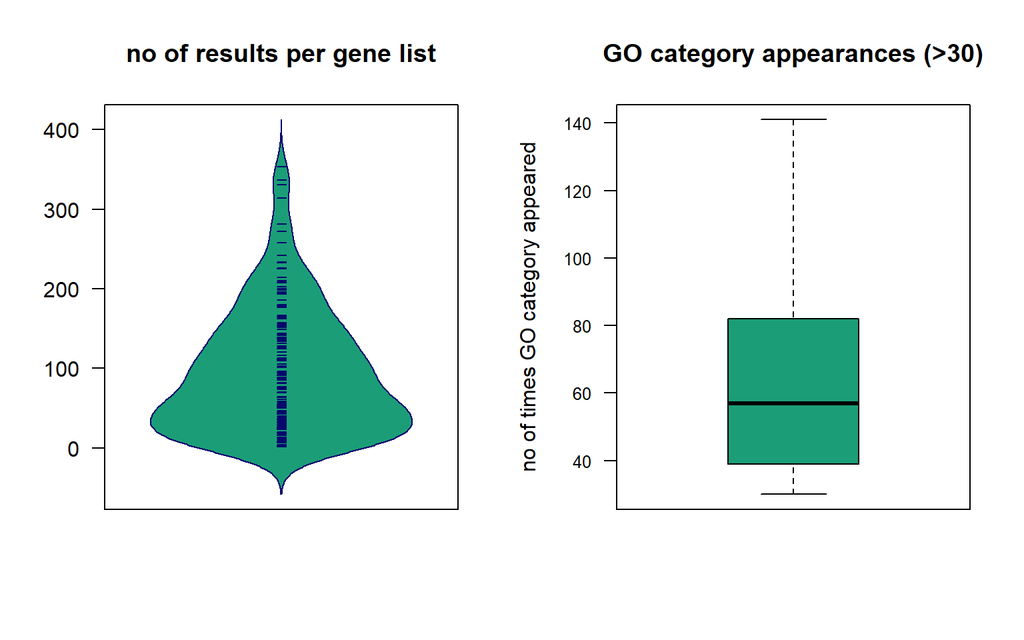

Each line on the beanplot shows the number of significant (corrected p-value < 0.05) functional categories returned from gene ontology analysis.

Laura Biggins

2019-10-22